# Simulation: One Latent Ordering

Ziang Zhang

## Question and design

Can a single MPCurve ordering recover a known sample trajectory from noisy two-dimensional observations? We use the spiral generator from the [MPCurver getting-started article](https://aguerozz.github.io/MPCurver/articles/mpcurve_intro.html): 1,000 samples with latent $t\in[1.5\pi,4.5\pi]$ and Gaussian noise standard deviation 0.12. The simulation seed is 1. A CAVI fit uses Fiedler initialization, $K=60$ grid positions, and at most 120 iterations. The fit uses MPCurver 0.3.4.

## Ordering recovery

Figure 1 compares the generating and inferred positions on the simulated spiral.

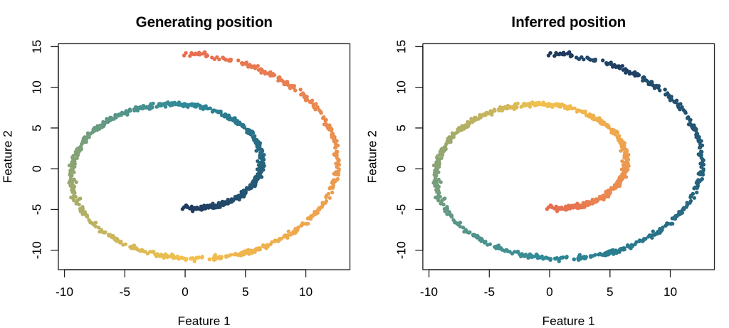

Figure 1. The simulated spiral coloured by the generating position (left) and the inferred posterior-mean grid position (right).

The absolute Spearman correlation between true $t$ and inferred posterior-mean grid position is **0.9997**. The absolute value accounts for the arbitrary direction of an inferred ordering. This result comes from one simulated data set.

## Objective trace

Figure 2 shows the ELBO recorded during the fit.

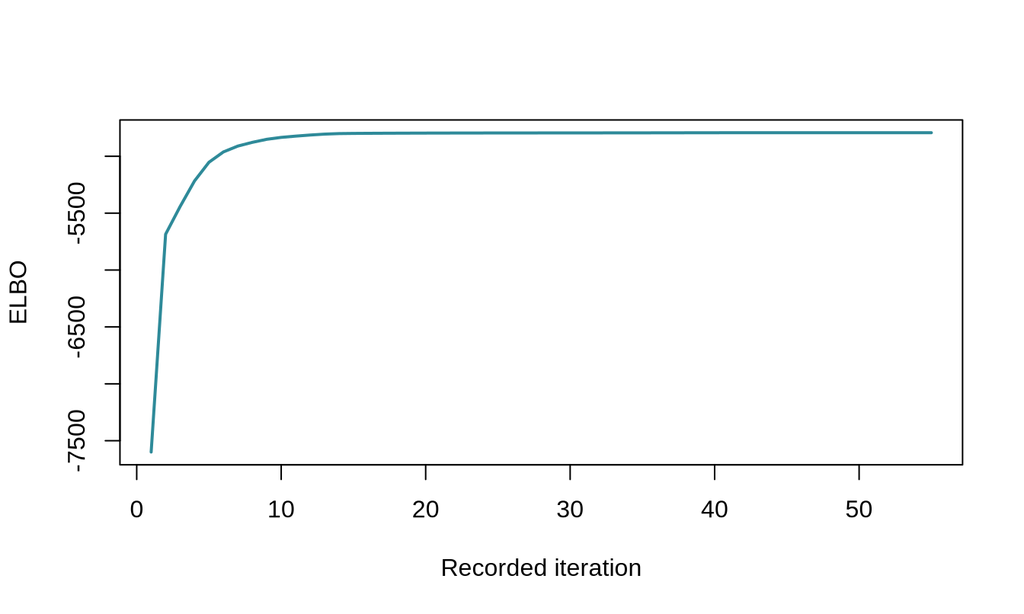

Figure 2. Evidence lower bound recorded during the single-ordering CAVI fit.

The ELBO increases through the fit and levels off as CAVI converges after **55 recorded iterations** under the normalized per-observation convergence rule.

## Reproduce

The [experiment script](https://github.com/AgueroZZ/InferOrder/blob/master/experiments/mpcurve_v034_site/run_simulations.R) regenerates the data, fit, and figures with MPCurver 0.3.4. The [saved results](https://github.com/AgueroZZ/InferOrder/tree/master/experiments/mpcurve_v034_site/results/simulations) include the generating truth and fitted model.